[figure not shown]

# Project management Techniques: WBS , CPM, PERT, Critical Chain

**Business informational systems**  
**Assoc. prof. Darko Etinger, Ph.D.**

## The evolution of project management (1/2)

Ever since the Industrial Revolution, managers have been seeking better ways to manage projects and increase worker productivity. Henry Gantt came up with his famous chart after working as a mechanical engineer for steel manufacturers. **The Gantt chart** , with its detailed records of time allocated and spent, provided a way for foremen and factory floor supervisors to track progress and measure worker efficiency.

Over the course of the 20th century, project management evolved as a discipline. In the 1950s, we saw the rise of **Work Breakdown Structures, Critical Path and PERT** . In the late 1990s, **Critical Chain** was introduced. And in 2001, a group of software developers met in Utah and published the **Agile Manifesto** .

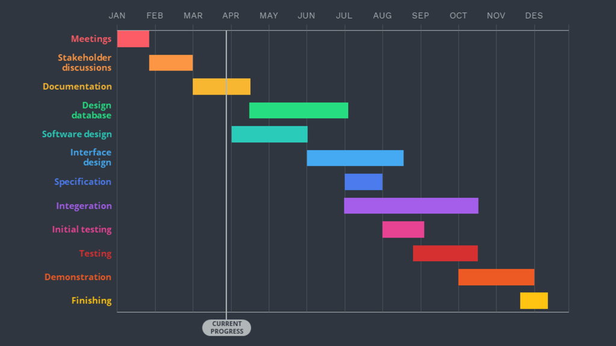

## The evolution of project management (2/2)

According to the International Journal of Project Management, all project management systems have two dimensions:

- Technical - tools and processes
- Human - team members and their expertise in subject areas

Each dimension contributes to performance and productivity and can be organized in infinite ways.

As technology pushes forward, project management changes with it. While mechanical engineering in the early 1900s required more rigid scheduling, **software developers today need more flexibility and immediate feedback** . **Agile** draws its strength from short tasks, daily stand-up meetings, and a free-form **Scrum** or **Kanban board** . In other industries, tools and teams look very different.

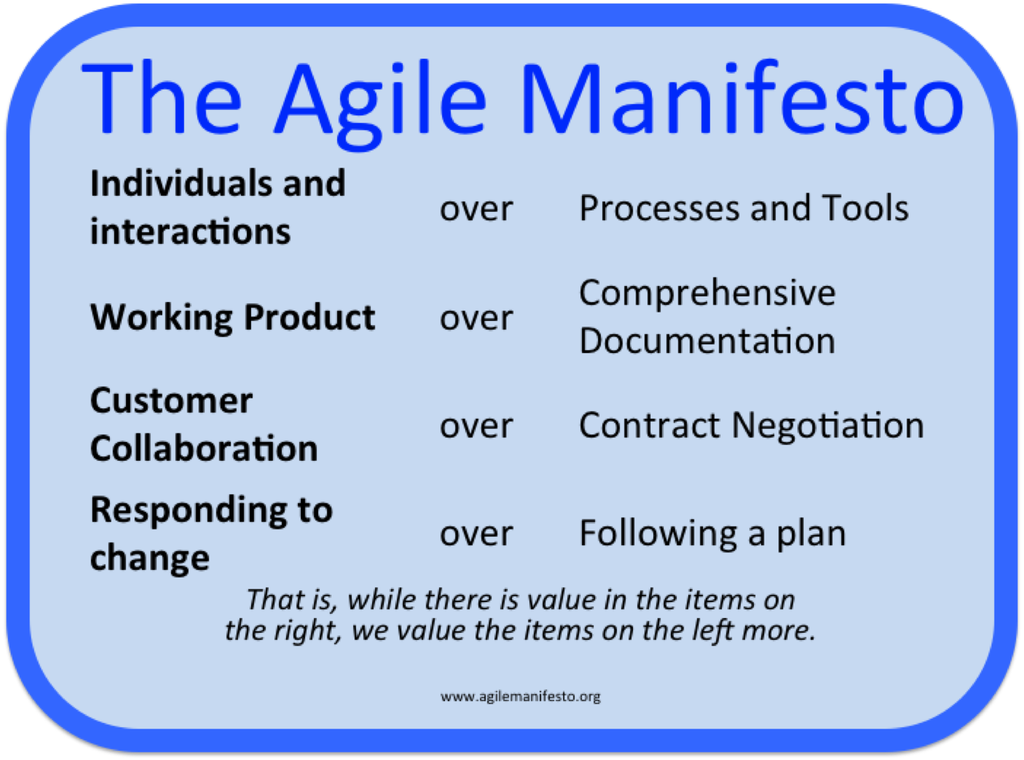

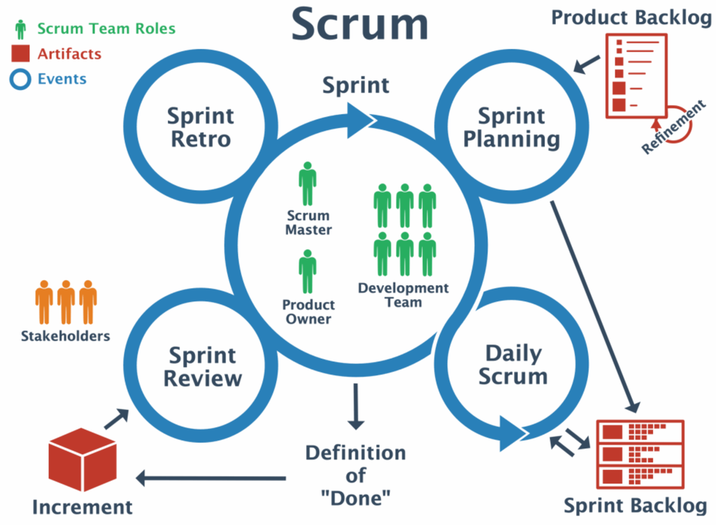

# Work Breakdown Structure (WBS)

Without a comprehensive task list, deadlines won't be helpful. The Work Breakdown Structure, also developed by the US Department of Defense in the late 1950s, is a **system for breaking a project down into manageable parts, including phases, deliverables, and work packages** . The parts are all represented on a tree chart.

By **focusing mainly on task lists and resource distribution** rather than deadline events, WBS is complementary to CPM and PERT.

The WBS chart is like a visual outline for your project. Tasks are assigned different levels, such as 1. final deliverable, 1.1 tasks, 1.1.1 sub-tasks, as shown in the example diagram for building a house.

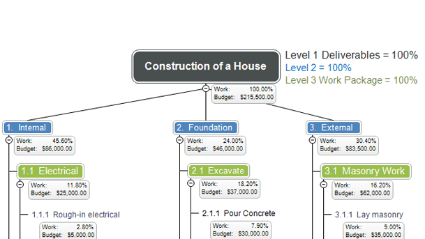

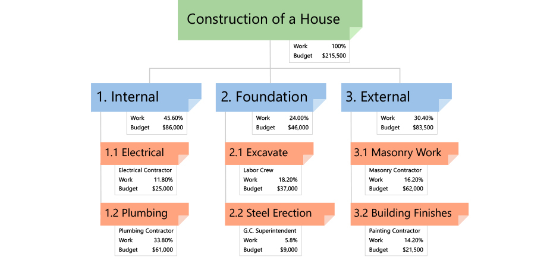

One of the main features of dividing a project according to WBS is that all the elements have to add up to the whole. A task cannot be considered complete if 100% of the subtasks are not complete, and the project is not complete without 100% of the tasks.

Some of the key benefits of the WBS process:

- Breaks down big events into manageable parts
- Defines the hierarchy of parent and child tasks
- All parts add up to the whole
- Categorizes work

Some of the drawbacks of WBS:

- Not a full project plan
- Doesn't plot time
- Doesn't say how tasks will get done or by whom

# Critical path method (CPM)

## CPM (1/2)

The Critical Path Method (or Critical Path Analysis - CPA) is defined in the **Project Management Body of Knowledge (PMBOK)** as follows:

> The Critical Path Method is the sequence of scheduled activities that determines the duration of the project.

These scheduled activities **must be performed and completed in a specific order** if the project is to be considered a success.

The CPM describes the **longest sequence of tasks** in the project.

## CPM (2/2)

Each task takes a different amount of time and resources.

The **total time** taken to complete the sequence along this critical path would give you an idea of the project’s **minimum duration** .

You might undertake several task sequences simultaneously, but if there are any delays in the critical path sequence, your project will suffer delays as well.

Critical Path Method is essentially **an algorithm for decision making** . This algorithm takes a task's start time, its duration, and finish time to figure out which activities deserve the most attention (ie are "critical" for the project).

## Critical Path: Basic Steps

The technique for figuring out the critical path in your project can be boiled down to four essential steps:

1. List all the tasks needed to complete the project. You can use a **work breakdown structure** , which is a hierarchical decomposition of the project, noting every deliverable.
2. Note the duration of each of those tasks, such as how long each one is going to take to complete it and move onto the next one.
3. If there are any task dependencies, you want to collect them, too. A task dependency is when one task cannot start until another one has been completed. It's a key element of good task management.
4. What are the milestones in the project? That being the major phases. Also, what are the deliverables? Create a list of these.

The critical path method calculates the early start and finish dates and late start and finish dates for all scheduled activities. It is the sequence of activities from start to the end of the project. The method is based on mathematical calculations and it is used for scheduling project activities. To identify the critical path in a project, determine the following four parameters:

**Earliest start time (ES)** : The time an activity can start once the previous dependent activities are over. **Earliest finish time (EF)** : ES + activity duration. L **atest finish time (LF)** : The time an activity can finish without delaying the project. **Latest start time (LS)** : LF - activity duration.

The critical path is the longest path through the schedule with either zero or negative total float. And a significant advantage of CPM is to complete the project in the shortest time possible with other advantages like visual representation of the project activities, tracking critical activities

If other constraints that might change the project schedule are considered and accounted for, the critical path method will be more accurate.

If **time is added** to the project because of these constraints, that is called a **critical path drag** , which is how much longer a project with take because of the task and constraint.

You may find that you need to complete a project **earlier** than your Critical Path Analysis says it is possible. In this case, you need to re-plan your project.

You have a number of options and would need to **assess the impact** of each on the project's **cost, quality and time** required to complete it.

For example, you could increase the resource available for each project activity to bring down time spent on each but the impact of some of this would be insignificant and a more efficient way of doing this would be to look only at activities on the critical path.

In some situations, **shortening the original critical path of a project can lead to a different series of activities becoming the critical path** .

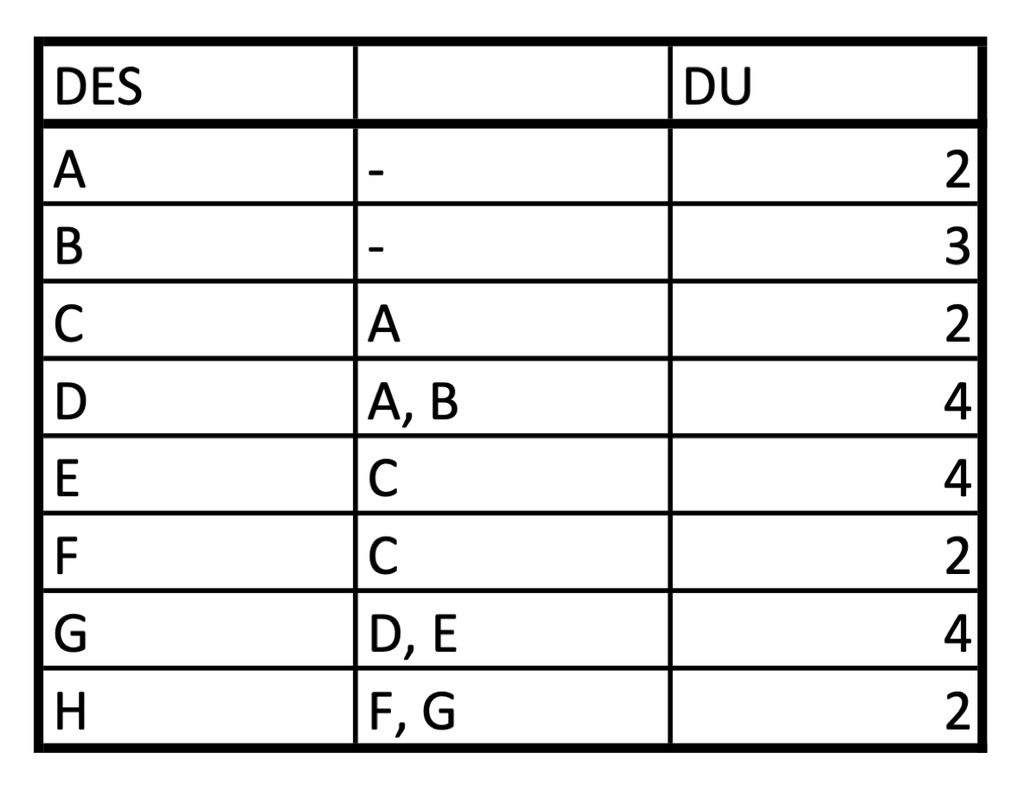

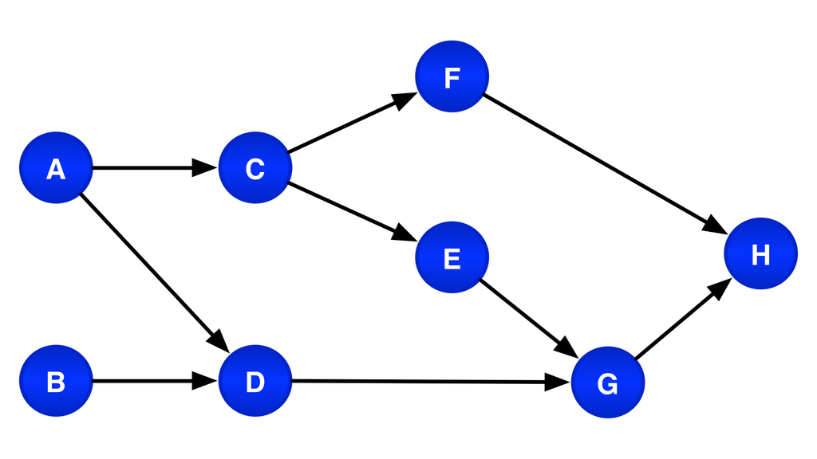

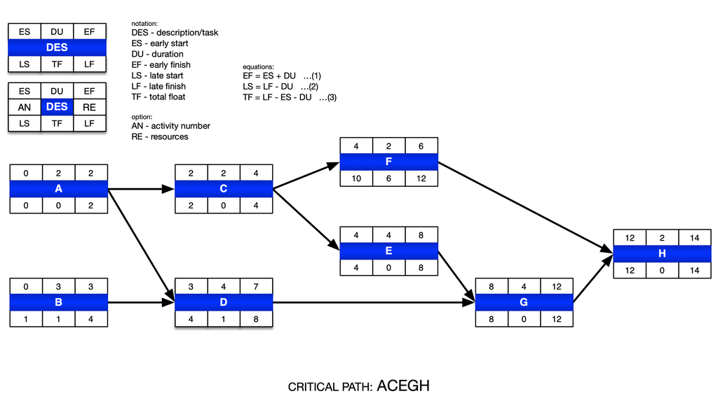

# Program Evaluation Review Technique - PERT (1/3)

Created in 1957 by the US Navy for its Polaris submarine missile program. Its focus on hard deadlines provided much-needed efficiency to the production process.

PERT is centered around **important dates** , known as **milestones** . The most important milestone is the final due date, and managers work backwards from there. To get from one milestone to the next, employees must complete tasks.

The project manager identifies tasks that must occur in sequence, known as **serial or dependent tasks** , and those that can be done at the same time, known as **parallel or concurrent tasks** .

In a PERT chart, the project is plotted out on a flowchart where the nodes are deadlines or milestones, and the arrows represent dependent tasks. Dependencies are represented by the linked pathways that move from left to right.

## PERT (2/3)

PERT was revolutionary in its method to calculate deadlines. A traditional PERT analysis averages three different timelines - **the shortest, realistic, and worst-case** - to predict likely due dates.

The exact for mula for deadlines is:

$$\frac{optimistic\ time + 4\ \times
most\ likely\ time + pessimistic\ time}{6}$$

You can also plot out the results of your PERT analysis on a Gantt chart, which shows durations and dependencies. The PERT chart can help during the project planning phase, and the Gantt chart can track time usage as the project progresses.

## PERT (3/3)

Some of the benefits of PERT include:

- Making uncertain deadlines more predictable
- A clear order to complete tasks
- Dependencies made explicit

But there is one major downside:

- Bottlenecks. If the calculations are inaccurate, any delay will create a bottleneck and affect the final delivery date.

Nevertheless, if you are looking to add structure and reduce uncertainty in project planning, PERT will help you set up important milestones and tasks to get you there.

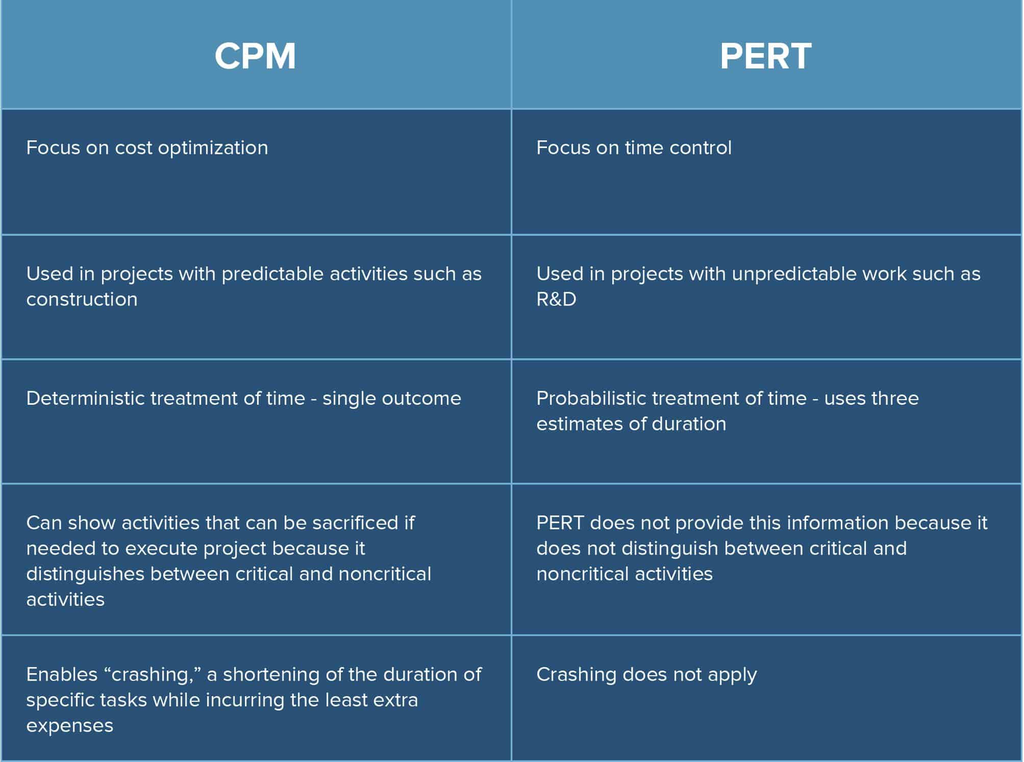

# Critical Chain

## Critical Chain (1/3)

Critical Chain Project Management method is introduced in Eliyahu Goldratt's business novel Critical Chain. The methodology was developed and published by Dr. Eliyahu M. Goldratt in 1997. Goldratt formulated the critical chain method within the framework of his Theory of Constraints (TOC). Dr. Goldratt focused his research on the following factors that affect the completion of project tasks:

- Student Syndrome: Starting the task at the latest possible moment.
- Parkinson's Law: Determining the completion of the task throughout the assigned full duration.
- Multitasking: Working on multiple tasks simultaneously and thus not being committed to any one task, introducing major delays in completing tasks.

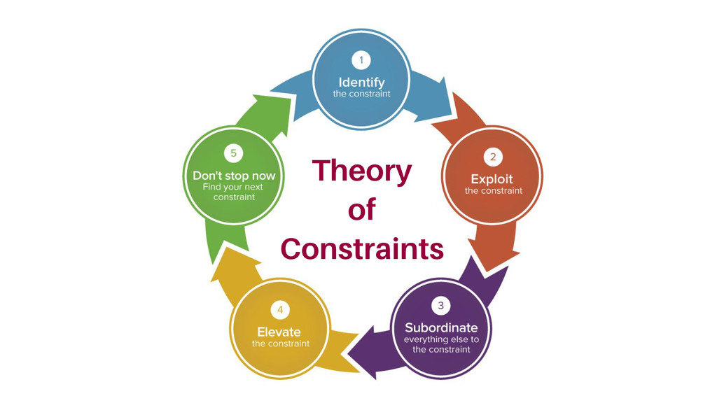

## Critical Chain (2/3)

According to many project management professionals, Goldratt's Critical Chain is thought to be the most significant contribution to project management since the introduction of the PERT system and the critical path method. Those who are practicing this methodology find it a good alternative to the established standard of Project Management as advocated by PMBOK®.

One of the popular ways to analyze projects is Critical Chain Project Management (CCPM). Let's together figure it out what it is. In this article, we'll provide a brief overview of the principles of Critical Chain Project Management and its applicability to managing projects.

[figure not shown]

## Critical Chain (3/3)

Putting a primary focus on the resources needed to complete the project's tasks, critical chain method begins by building a project schedule and identifying the most crucial tasks that need to be done and reserving resources for those high-priority tasks.

Critical chain method does not rely primarily on estimates. Such an approach allows managers to eliminate uncertainties and use safety buffers to level down risks and ensure the stability of a plan. It comes into action after the preparation of the initial project schedule that includes the establishing task dependencies. The evolved critical path is reworked based on the Critical Chain Method.

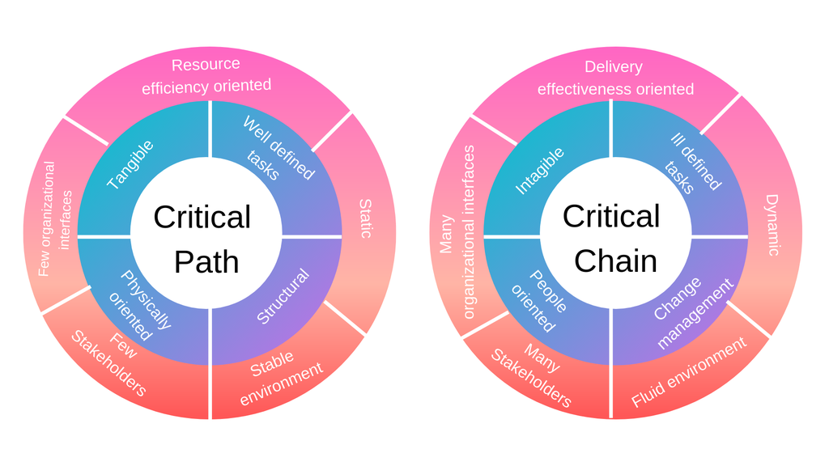

Using the Critical Chain Method, projects can be completed more quickly and with greater scheduling safety. It modifies the project schedule to account for limited resources by adding duration buffers that are non-work schedule activities. Critical chain is completed after fixing the critical path by entering resource availability, managing remaining buffer durations against the remaining duration of task chains.

To account for the uncertainty associated with the critical chain, you add buffers. What is a buffer in project management? A buffer gives project managers space when unexpected events occur and is connected with scheduling in project management. Buffer at the end of the project is used to protect the delivery date.

## Project Buffer in Critical Chain Management

A single Project buffer at the end of a project is the main tool to manage risk in CCPM. It is put at the end in between the last task and the date of completion. It helps to keep the completion date the same despite any delays. Those delays consume buffer time what allows protecting the completion date.

Feeding buffers are time buffers added between last assignments in different groups. Capital buffers are reserve funds for contingencies. Inventory buffers are unreleased work to be released when projects go better. Resource buffer ensures that resources are available in case they are needed.

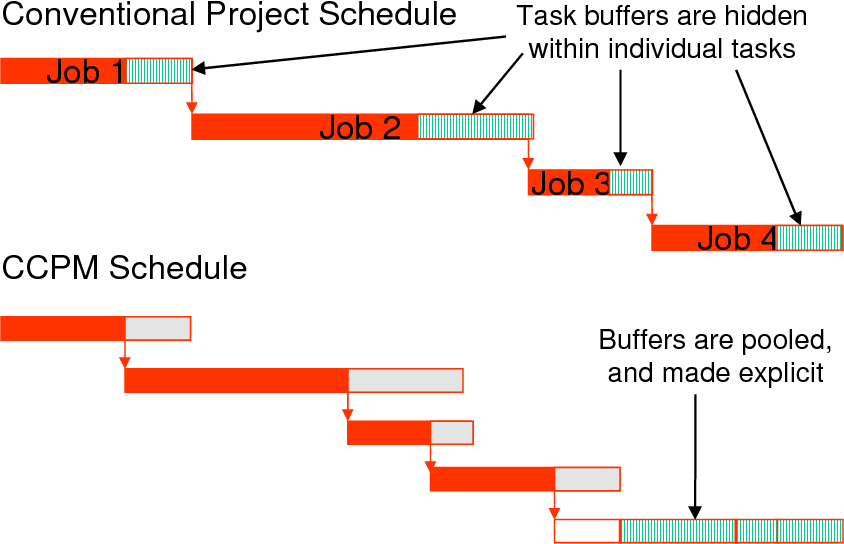

## Using the Critical Chain Method in Project

Here's how you can create a successful critical chain project management process:

#### 1. Exploit the Constraint

With the start of a project, project management activities earlier have been based on constraints that sometimes delay the process. So you budget more time than you really need just to get finished on time. So the first step is to let people know what you're trying to achieve. Of course, you want the average time in which an activity can be completed to make sure everything goes well. After you've got all the information, you can start constructing your critical chain using the average time, plus a buffer that's between the best and worst-case scenarios.

#### 2. Eliminate Multitasking

Multitasking is the process of dropping a task before it is finished to start another and start yet another or go back to previous. It goes out of the window because you probably can't do several things at once and still focus on each one to the full. Your projects will expect 100 percent focus on the task at hand.

#### 3. Limit your team's focus

When following the critical chain methodology for your projects, it's important to keep your team focused on individual tasks as it will lead to more productive, harmonious, collaborative behaviors. This will also add to timely task completion and efficiency.

#### 4. Create 50/50 time estimates

The critical chain process idea is a great idea to avoid wasted time and push the team members towards a more efficient timeline. Successful critical chain processes cut the estimated time needed for projects. Sometimes employees procrastinate, this practice will push them to complete their tasks on time.

#### 5. Implement buffers for uncertainties

Buffers provide information on when and where recovery is needed, a buffer plan can inform you if the buffer can be removed. After you cut the estimated time needed by 50%, the remaining time can then be used as a buffer. It acts as a shock absorber for the project. Implementing project buffers with the CCPM process leads to finishing projects 25% faster.

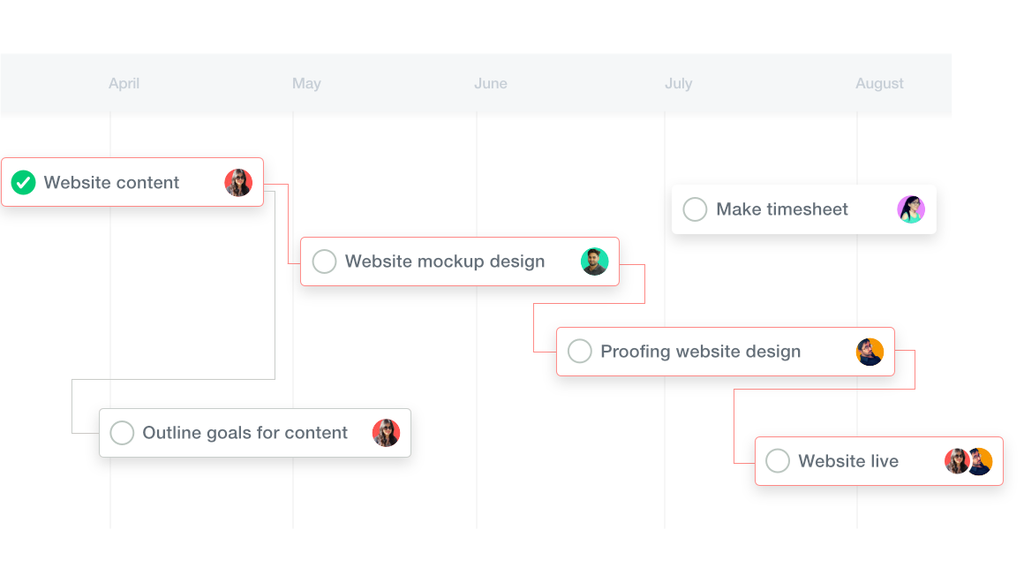